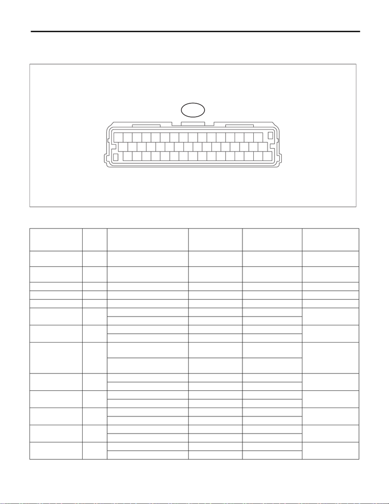

CVT(diag)-10

Transmission Control Module (TCM) I/O Signal

CONTINUOUSLY VARIABLE TRANSMISSION (DIAGNOSTICS)

5. Transmission Control Module (TCM) I/O Signal

A: ELECTRICAL SPECIFICATION

NOTE:

Measure after warming up.

Item

Te rmi -

nal No.

Measuring condition

Measurement

value

Resistance between

terminal and chassis

ground

Remarks

Backup power

supply

34 — 10 — 13 V —

Ignition power

supply

41 — 10 — 13 V —

Main power supply 8 — 10 — 13 V —

Main power supply 24 — 10 — 13 V —

Main power supply 40 — 10 — 13 V —

Manual mode

switch

20

Manual mode switch ON Less than 1 V —

Manual mode switch OFF 8 V or more —

Manual mode UP

switch

19

Manual mode UP switch ON Less than 1 V —

Manual mode UP switch OFF 8 V or more —

Manual mode

DOWN switch

18

Manual mode DOWN switch

ON

Less than 1 V —

Manual mode DOWN switch

OFF

8 V or more —

Stop light switch 29

Stop light switch ON 8 V or more —

Stop light switch OFF Less than 1 V —

P range switch 38

P range Less than 1 V —

Except for P range 8 V or more —

R range switch 37

R range Less than 1 V —

Except for R range 8 V or more —

N range switch 36

N range Less than 1 V —

Except for N range 8 V or more —

D range switch 35

D range Less than 1 V —

Except for D range 8 V or more —

B54

123456789

CVT00515

TO

[figure not shown]

CVT(diag)-11

Transmission Control Module (TCM) I/O Signal

CONTINUOUSLY VARIABLE TRANSMISSION (DIAGNOSTICS)

ATF temperature

sensor

6

ATF temperature at 20°C

(68°F)

Approx. 2.6 V Approx. 2.6 kΩ

ATF temperature at 80°C

(176°F)

Approx. 0.7 V Approx. 370 Ω

ATF temperature

sensor GND

1 Always Approx. 0 V —

Secondary pres-

sure sensor power

supply output

33 Ignition switch ON 5 V —

Secondary pres-

sure sensor

5

Ignition switch ON, engine

OFF

Approx. 0.5 V

(0 MPa)

—

Value increases with

increase of engine

load. (0.5 — 4.5 V)

Ignition switch ON, engine ON

Approx. 1.0 V

(1.0 MPa)

—

Secondary pres-

sure sensor GND

2 Always Approx. 0 V —

Primary speed

sensor

14 While driving 0 or 5 V —

Refer to the wave-

form (sensor)

Secondary speed

sensor

13 While driving 0 or 5 V —

Refer to the wave-

form (sensor)

Front wheel speed

sensor

12 Engine ON, “P” or “N” range 0 or 5 V —

Refer to the wave-

form (sensor)

Rear wheel speed

sensor

11 Engine ON, “P” or “N” range 0 or 5 V —

Refer to the wave-

form (sensor)

Self shut output 25

For three seconds after igni-

tion switch ON and OFF

Less than 1 V

—

Ignition switch OFF 8 V or more

F&R solenoid 16 Engine ON

Refer to the wave-

form (solenoid (1))

Approx. 4 — 6 Ω

Resistance value at

20°C (68°F). Value

is higher as the tem-

perature increase.

Secondary sole-

noid

32 Engine ON

Refer to the wave-

form (solenoid (2))

Approx. 5 — 7 Ω

Resistance value at

20°C (68°F). Value

is higher as the tem-

perature increase.

Primary UP sole-

noid

47 Engine ON, while UP shifting

Refer to the wave-

form (solenoid (3))

Approx. 10 — 13.5 Ω

Resistance value at

20°C (68°F). Value

is higher as the tem-

perature increase.

Primary DOWN

solenoid

30

Engine ON, while DOWN

shifting

Refer to the wave-

form (solenoid (4))

Approx. 10 — 13.5 Ω

Resistance value at

20°C (68°F). Value

is higher as the tem-

perature increase.

Lock-up duty sole-

noid

15 Lock-up ON

Refer to the wave-

form (solenoid (5))

Approx. 10 — 13.5 Ω

Resistance value at

20°C (68°F). Value

is higher as the tem-

perature increase.

AWD solenoid 48

Engine ON, “P” or “N” range

Refer to the wave-

form (solenoid (6))

Approx. 2 — 4.5 Ω

Resistance value at

20°C (68°F). Value

is higher as the tem-

perature increase.

Engine ON, “D” range, brake

ON

Refer to the wave-

form (solenoid (7))

Lock-up ON/OFF

solenoid

31

With lock-up OFF Less than 1 V

Approx. 13 — 18.5 Ω

Resistance value at

20°C (68°F). Value

is higher as the tem-

perature increase.

With lock-up ON and in “R”

range

Battery voltage or

higher

Item

Te rmi -

nal No.

Measuring condition

Measurement

value

Resistance between

terminal and chassis

ground

Remarks

[figure not shown]

CVT(diag)-12

Transmission Control Module (TCM) I/O Signal

CONTINUOUSLY VARIABLE TRANSMISSION (DIAGNOSTICS)

B: WAVEFORM

1. SENSOR

CAN communica-

tion line (+)

43 — — —

CAN communica-

tion line (–)

44 — — —

GND 26 Always Approx. 0 V —

GND 42 Always Approx. 0 V —

Item

Te rmi -

nal No.

Measuring condition

Measurement

value

Resistance between

terminal and chassis

ground

Remarks

2V

0

FREQUENCY

CHANGES ALONG

WITH THE SPEED.

[figure not shown]

CVT(diag)-13

Transmission Control Module (TCM) I/O Signal

CONTINUOUSLY VARIABLE TRANSMISSION (DIAGNOSTICS)

2. SOLENOID

AT-05529

2ms

(1)

0V

5V

AT-05531

50ms

(2)

0V

5V

AT-05532

1ms

(3)

0V

10V

AT-05530

1ms

(4)

0V

10V

AT-05526

1ms

(5)

0V

10V

AT-05527

10ms

(6)

0V

10V

AT-05528

1ms

(7)

0V

10V